# Introduction:

# Plots

**Fig 1** - Pairplot between Age and passenger class categorized by 'Survived'.  
**Analysis** - This plot compares the age and passenger class of those who survived vs those who died. Looking at the 1st plot on the 2nd row with hue survived, we can see see that status 0 or 'Died' points are clustered more towards the right of the plot (higher age values) and we see more of these points on Pclass=3 rather than Pclass=1. The 4th plot shows the green bar or 1 status or 'Survived' status to be much larger for Pclass=1 as opposed to Pclass = 3 and the exact proportion of this will be clear in the next plot.  
**Result**From the plot, we can see that the majority of passengers who died belong to the 3rd class as opposed to the 2nd or 1st classes (with 3>2>1) and among those the people who survived were fairly young.

- 1 denotes passenger survived and 0 denotes passenger died.

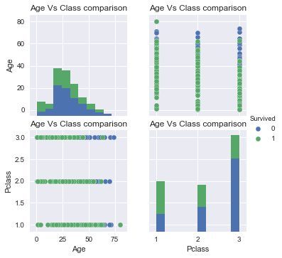

```python
agevsclass = sns.pairplot(titanic_noNA,hue='Survived',vars=['Age','Pclass'])
agevsclass.set(title='Age Vs Class comparison')
```

**Fig 2** bar plot of survival rate by class.  
**Analysis** Survival rate of Pclass = 1 was 63%, Pclass=2 was 47% and Pclass=3 was 24%. Clearly, the percentage of passengers who survived was higher in the upper classes compared to the lower with order of survival being 1>2>3.  
**Result** Only a 24% survival rate among class 3 passengers indicates that either upper classes were prioritized over lower classes or that lifeboats were more easily accessible from the 1st class section of the boat rather than the 2nd or 3rd class.

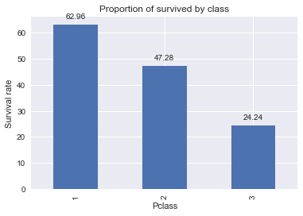

```python
prop = titanic_df.groupby('Pclass')['Survived'].mean()*100.

plt.ylabel('Survival rate')
ax = prop.plot(kind="bar", title="Proportion of survived by class")
for p in ax.patches:

    ax.annotate("%.2f" % p.get_height(), (p.get_x() + p.get_width() / 2., p.get_height()), ha='center', va='center', xytext=(0, 10), textcoords='offset points')
```

**Fig 3** - Factorplot visualizing passenger survival based on sex and class.  
**Analysis** Looking at the green line representing female passengers, the survival rate tapers off as we move right along the x-axis (with increasing Pclass). Following the blue line, we see it follows a similar pattern from left to right along the x-axis. Looking at each male/female pairs of data points for each Pclass, we see that data points for males are much lower on the y-axis (survival rate axis) than the data points for females.  
**Result** We can deduce that a lot more women than men survived. It's importan to look at the survival rate of these two factors (Sex and Pclass) together because we see that among the women who survived, a lot more in the upper class survived than in lower classes. Therefore, in addition to preference given to upper class, priority was also given to female passengers.

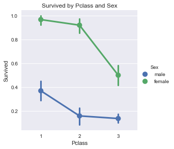

```python
pclass = sns.factorplot(data=titanic_df,x='Pclass',y='Survived',hue='Sex')
pclass.set(title='Survived by Pclass and Sex')
```

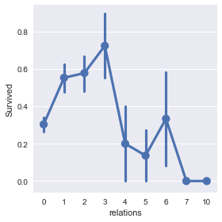

```python
titanic_df['relations'] = titanic_df['Parch']+titanic_df['SibSp']

relations = sns.factorplot(data=titanic_df,x='relations',y='Survived')
```

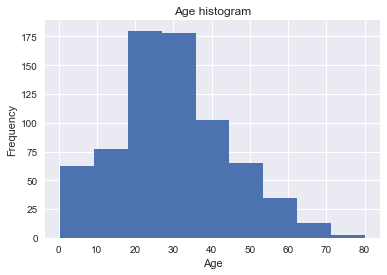

```python
#Fig 5 histogram of age of passengers on board which shows that most of the passengers on board were between 20 and about 38 years old.
#This data discards the passengers with missing NaN values for age and therefore as stated earlier, any new information
#about age has the potential to significantly alter the resulting findings.
plt.hist(titanic_noNA['Age'],bins=9)
plt.title('Age histogram')
plt.xlabel('Age')
plt.ylabel('Frequency')
```

# Assumptions and Limitations

- The dataset contains only a small fraction of information about the total number of passengers who were on board (about 40% of the total 2224). Therefore, any significant new information about the remaining passengers might alter the resulting findings.
- At this point however, I assume this sample is a fair representation of the population and any conclusions derived from the analyses can be extrapolated to the population.
- The data does not specify who is a child vs who is a parent but only whether a specific passenger travelled with a child or parent (similarly for a sibling/spouse relationship). Even though we can determine this based on the age of the passenger (atleast for a parent/child relationship), owing to the fact that we are missing a lot of data in the age column makes the classification by age difficult. Therefore while we can classify survival rate based on gender, the classification based on age is limited by the limited data available.
- Finally, the rows containing missing values in age, have been eliminated from the analysis. A new dataset titanic_noNA has been created that contains the filtered out data (without NaN). Therefore, any conclusions based on age (Ex. histogram of survived by age) is limited by the lack of information. Any new information about the missing rows might alter the results of the study.

# Links I referred to

https://www.kaggle.com/c/titanic/data http://stackoverflow.com/questions/17071871/select-rows-from-a-dataframe-based-on-values-in-a-column-in-pandas http://seaborn.pydata.org/generated/seaborn.pairplot.html https://www.kaggle.com/benhamner/python-seaborn-pairplot-example/code https://bespokeblog.wordpress.com/2011/07/11/basic-data-plotting-with-matplotlib-part-3-histograms/ https://discussions.udacity.com/t/nan-rows-not-showing-up-in-search/248475/7 https://discussions.udacity.com/t/nan-with-random-values/248494/5